# Machine Learning Project

A.E. Hutson

March 20, 2015

## Introduction and Method

This paper is a brief look at the ability of sensors to correctly recognize one of five methods of doing a one-arm barbell curl. Users wore an arm band, glove, and a belt, all with sensors to detect movement (e.g., acceleration, magnetometer, gyro, pitch).

First, the data must be transformed. An examination of the dataset (using the ‘summary’ function) revealed that there were many columns with NA values. There are also columns with timestamps and users names; we don’t care about these variables, so why not remove them?

```r
# Find the variables with NA values
    excludeVariable <- vector()
    for (i in 8:(length(dataSet)-1)) { # for each of the columns besides the last
        if (sum(is.na(dataSet[i] > 0)) > 10000) { # if the number of nas > 10000
            excludeVariable <- append(excludeVariable, i) # exclude the variable
            }
        }
```

```r
dataSet <- dataSet[,-excludeVariable]  # create new data set with variable
dataSet <- dataSet[,8:length(dataSet)]  # remove all of the descriptives

inTrain <- createDataPartition(y=dataSet$classe, p=0.7, list=FALSE)
train <- dataSet[inTrain, ]
test <- dataSet[-inTrain, ]

finaltest <- FinalTesting[,-excludeVariable]  # create new data set with variable
    finaltest <- finaltest[,8:length(finaltest)]  # remove all of the descriptives
```

First, we can create a graph of the data using qplot and the two variables with the highest correlation to classe. The graph below shows that there is a lot of overlap between classes on the two top variables.

```r
# Save the correlations between the training variables
classCorrs <- apply(train ,2, function(col)cor(as.numeric(col), as.numeric(train$classe)))
# Print the order of the correlations
order(abs(classCorrs))
```

```
##  [1] 49 18 38  9  2 20 46 33 31 35  5 45  8 44 19 29  6 40 48  3  7 11 42
## [24] 52 32 30 27 16 23 36  1 37 28 14  4 10 22 34 51 17 39 26 43 15 13 50
## [47] 47 21 25 12 24 41 53
```

```r
# These two variables have the highest correlations with classe
classCorrs[41] # pitch_forearm
```

```
## pitch_forearm
##        0.3504
```

```r
classCorrs[24] # magnet_arm_x
```

```
## magnet_arm_x
##       0.2998
```

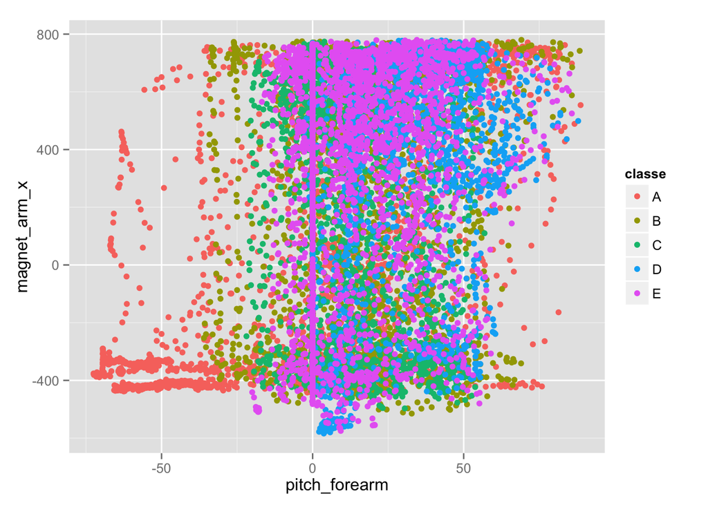

```r
qplot(pitch_forearm, magnet_arm_x, color=classe, data=train)
```

Let’s try to make a model of the data using a classification tree.

```r
modFit <- train(classe~., method='rpart', data=train)
# This tells what the nodes are and the final splits, and what the probability of being in a class is based on the split.
print(modFit$finalModel)
```

```
## n= 13737
##
## node), split, n, loss, yval, (yprob)
##       * denotes terminal node
##
##  1) root 13737 9831 A (0.28 0.19 0.17 0.16 0.18)
##    2) roll_belt< 129.5 12491 8628 A (0.31 0.21 0.19 0.18 0.11)
##      4) pitch_forearm< -33.95 1123    6 A (0.99 0.0053 0 0 0) *
##      5) pitch_forearm>=-33.95 11368 8622 A (0.24 0.23 0.21 0.2 0.12)
##       10) magnet_dumbbell_y< 432.5 9526 6848 A (0.28 0.18 0.24 0.19 0.1)
##         20) roll_forearm< 122.5 5851 3469 A (0.41 0.18 0.19 0.17 0.056) *
##         21) roll_forearm>=122.5 3675 2451 C (0.081 0.18 0.33 0.23 0.18) *
##       11) magnet_dumbbell_y>=432.5 1842  909 B (0.037 0.51 0.042 0.23 0.19) *
##    3) roll_belt>=129.5 1246   43 E (0.035 0 0 0 0.97) *
```

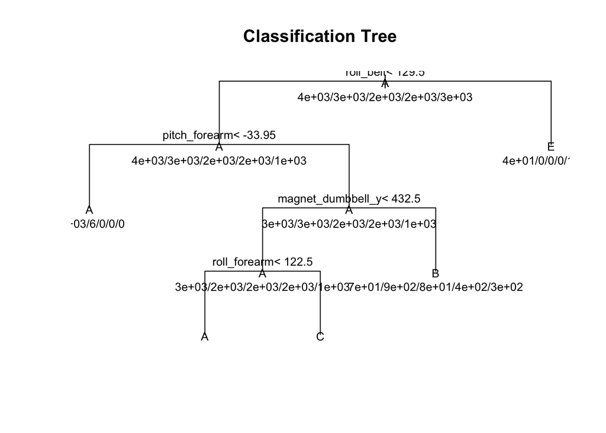

```r
# Let's plot it
plot(modFit$finalModel, uniform=TRUE, main="Classification Tree")
text(modFit$finalModel, use.n=TRUE, all=TRUE, cex=.8)
```

```r
# Predict new values -- this will actually write out the class
testClass <- predict(modFit, newdata=test)

confusionMatrix(testClass,test$classe)  # overall accuracy was 50%
```

```
## Confusion Matrix and Statistics
##
##           Reference
## Prediction    A    B    C    D    E
##          A 1496  484  487  419  159
##          B   39  387   37  184  129
##          C  108  268  502  361  298
##          D    0    0    0    0    0
##          E   31    0    0    0  496
##
## Overall Statistics
##
##                Accuracy : 0.49
##                  95% CI : (0.477, 0.502)
##     No Information Rate : 0.284
##     P-Value [Acc > NIR] : <2e-16
##
##                   Kappa : 0.333
##  Mcnemar's Test P-Value : NA
##
## Statistics by Class:
##
##                      Class: A Class: B Class: C Class: D Class: E
## Sensitivity             0.894   0.3398   0.4893    0.000   0.4584
## Specificity             0.632   0.9180   0.7870    1.000   0.9935
## Pos Pred Value          0.491   0.4987   0.3266      NaN   0.9412
## Neg Pred Value          0.937   0.8528   0.8795    0.836   0.8906
## Prevalence              0.284   0.1935   0.1743    0.164   0.1839
## Detection Rate          0.254   0.0658   0.0853    0.000   0.0843
## Detection Prevalence    0.517   0.1319   0.2612    0.000   0.0895
## Balanced Accuracy       0.763   0.6289   0.6381    0.500   0.7260
```

The confusion matrix for the simple classification tree model demonstrates that the model was not very accurate at predicting the outcome variable, particularly for type “D”.

A random forest model should improve the predictions significantly. A random forest lets you bootstrap samples and variables to grow multiple trees and then pick the best combination of variables.

```r
library(caret)
# fit model using train, rf=random forest. prox = true produces a bit more info
modFit <- train(classe ~ ., data=train, method='rf', prox=TRUE)
```

## Results

The original data set was split into a training set (70% of values) and a testing set (30% of values) so that cross validation could be performed. Let’s predict those new values and run them through the confusion matrix.

```r
# Predict new values
testClass <- predict(modFit, newdata=test)
confusionMatrix(testClass,test$classe)  # overall accuracy was 50%
```

```
## Confusion Matrix and Statistics
##
##           Reference
## Prediction    A    B    C    D    E
##          A 1674    8    0    0    0
##          B    0 1129    5    1    1
##          C    0    2 1019   14    4
##          D    0    0    2  948    6
##          E    0    0    0    1 1071
##
## Overall Statistics
##
##                Accuracy : 0.993
##                  95% CI : (0.99, 0.995)
##     No Information Rate : 0.284
##     P-Value [Acc > NIR] : <2e-16
##
##                   Kappa : 0.991
##  Mcnemar's Test P-Value : NA
##
## Statistics by Class:
##
##                      Class: A Class: B Class: C Class: D Class: E
## Sensitivity             1.000    0.991    0.993    0.983    0.990
## Specificity             0.998    0.999    0.996    0.998    1.000
## Pos Pred Value          0.995    0.994    0.981    0.992    0.999
## Neg Pred Value          1.000    0.998    0.999    0.997    0.998
## Prevalence              0.284    0.194    0.174    0.164    0.184
## Detection Rate          0.284    0.192    0.173    0.161    0.182
## Detection Prevalence    0.286    0.193    0.177    0.162    0.182
## Balanced Accuracy       0.999    0.995    0.995    0.991    0.995
```

The model appears to be very accurate, with an accuracy rate of 99.3%. The item with the most incorrect prediction was D (incorrectly identified as C about 2% of the time. A plot of the correct and incorrect values is below.

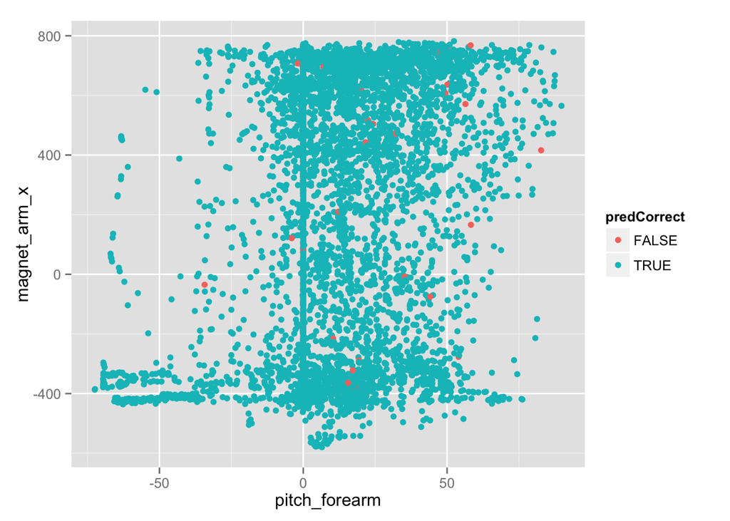

```r
test$predCorrect <- testClass==test$classe # code if prediction was right
# Plot the data again, and color the incorrect points red.
qplot(pitch_forearm, magnet_arm_x, color=predCorrect, data=test)
```

The items that it missed are primarily from 0-50 in pitch_forearm. Possibly adding another sensor to the forearm would help improve accuracy even further.